# Project tasks : Obesity microbiome

Authors

Affiliations

dr.sc. Paula Štancl

Kuzman Consulting d.o.o

dr.sc. Andrea Gelemanović

MedILS, UNIST

# Microbiome dataset

The study by Le Chatelier et al. found that individuals with obesity who have lower bacterial richness in their gut (low gene count - LGC) tend to have more severe metabolic issues like increased overall adiposity, dyslipidemia, insulin resistance, and inflammation compared to obese individuals with higher gut bacterial richness (high gene count - HGC). This suggests a link between gut microbiota composition and the severity of obesity-related complications.

This dataset was sourced from [Kaggle](https://www.kaggle.com/datasets/antaresnyc/metagenomics) and subsetted for this analysis. Kaggle is an online platform for data science and machine learning where users can find datasets, enter competitions, and share code through cloud-based notebooks. It also offers free courses and a community forum, making it a great place to learn, practice, and collaborate on real-world data problems.

## Organize your Rproject

Create a new project where you will save all the data, scripts and outputs for this Hackaton. Afterwards download the dataset:

- Download the dataset

Import your downloaded data into R using `fread()`

```r
# Data manipulation
library(data.table)
library(caret)
# Machine learning
library(caret)
library(MASS)
library(factoextra)
library(Boruta)
# Visualization
library(ggplot2)
library(ggpubr)        # For gghistogram, ggboxplot, ggscatter, stat_compare_means, stat_cor
library(corrplot)      # For correlation matrix plot

# Outlier detection
library(rstatix)       # identify_outliers
library(outliers)      # grubbs.test
library(EnvStats)      # rosnerTest

# Correlation matrix with p-values
library(Hmisc)         # rcorr

# Variance Inflation Factor (VIF) to check multicollinearity
library(car)          # vif
(microbiome <- fread("gut_obesity_subset.csv"))
```

| dataset_name | sampleID | bodysite | disease | bmi | s__Bacteroides_dorei | s__Bacteroides_dorei\|t__Bacteroides_dorei_unclassified | s__Bacteroides_uniformis | s__Bacteroides_uniformis\|t__Bacteroides_uniformis_unclassified | s__Bacteroides_vulgatus | s__Bacteroides_vulgatus\|t__Bacteroides_vulgatus_unclassified | s__Barnesiella_intestinihominis | s__Barnesiella_intestinihominis\|t__GCF_000296465 | s__Prevotella_copri | s__Prevotella_copri\|t__GCF_000157935 | s__Alistipes_putredinis | s__Alistipes_putredinis\|t__GCF_000154465 | s__Eubacterium_rectale | s__Eubacterium_rectale\|t__Eubacterium_rectale_unclassified | s__Eubacterium_siraeum | s__Eubacterium_siraeum\|t__Eubacterium_siraeum_unclassified | s__Butyrivibrio_crossotus | s__Butyrivibrio_crossotus\|t__GCF_000156015 | s__Coprococcus_sp_ART55_1 | s__Coprococcus_sp_ART55_1\|t__GCF_000210595 | s__Faecalibacterium_prausnitzii | s__Faecalibacterium_prausnitzii\|t__Faecalibacterium_prausnitzii_unclassified | s__Ruminococcus_bromii | s__Ruminococcus_bromii\|t__GCF_000209875 | s__Subdoligranulum_unclassified | … |
| --- | --- | --- | --- | --- | --- | --- | --- | --- | --- | --- | --- | --- | --- | --- | --- | --- | --- | --- | --- | --- | --- | --- | --- | --- | --- | --- | --- | --- | --- | --- |
| Chatelier_gut_obesity | MH0002 | stool | n | 27.3 | 1.43942 | 1.43942 | 3.04863 | 3.04863 | 4.86153 | 4.86153 | 0.41565 | 0.41565 | 0.00000 | 0.00000 | 2.72063 | 2.72063 | 29.69837 | 29.69837 | 8.26298 | 8.26298 | 0.00000 | 0.00000 | 0.00000 | 0.00000 | 2.49956 | 1.30381 | 0.00000 | 0.00000 | 10.07847 | … |
| Chatelier_gut_obesity | MH0003 | stool | obesity | 33.2 | 1.21322 | 1.21322 | 5.83949 | 0.00000 | 3.53846 | 3.53846 | 0.00000 | 0.00000 | 0.00000 | 0.00000 | 0.00000 | 0.00000 | 0.23823 | 0.23823 | 2.41306 | 2.41306 | 0.00000 | 0.00000 | 3.05168 | 3.05168 | 10.20875 | 9.60214 | 5.35383 | 5.35383 | 16.43483 | … |
| Chatelier_gut_obesity | MH0006 | stool | leaness | 22.4 | 1.71468 | 1.71468 | 0.15793 | 0.15793 | 0.84920 | 0.84920 | 0.88052 | 0.88052 | 37.22636 | 37.22636 | 5.09660 | 5.09660 | 0.04338 | 0.04338 | 0.00614 | 0.00614 | 10.92296 | 10.92296 | 0.00000 | 0.00000 | 5.81497 | 5.00889 | 2.45525 | 2.45525 | 8.50183 | … |
| Chatelier_gut_obesity | MH0009 | stool | n | 29.0 | 0.44990 | 0.44990 | 0.17671 | 0.17671 | 0.56213 | 0.56213 | 0.16079 | 0.16079 | 10.71595 | 10.71595 | 1.34318 | 1.34318 | 0.68889 | 0.68889 | 21.78243 | 21.78243 | 0.25799 | 0.25799 | 0.00000 | 0.00000 | 4.24856 | 2.36481 | 0.16027 | 0.16027 | 22.56461 | … |
| Chatelier_gut_obesity | MH0011 | stool | leaness | 22.3 | 0.00000 | 0.00000 | 1.25138 | 1.25138 | 2.00510 | 2.00510 | 3.22474 | 3.22474 | 0.00000 | 0.00000 | 5.83724 | 5.83724 | 2.09960 | 2.09960 | 0.60692 | 0.60692 | 0.00000 | 0.00000 | 0.00000 | 0.00000 | 13.35150 | 6.56500 | 2.00014 | 2.00014 | 14.22546 | … |
| Chatelier_gut_obesity | MH0012 | stool | obesity | 32.1 | 4.60583 | 4.60583 | 0.49233 | 0.49233 | 0.02685 | 0.02685 | 2.86031 | 2.86031 | 0.00000 | 0.00000 | 5.99304 | 5.99304 | 1.08598 | 1.08598 | 0.13035 | 0.13035 | 0.00045 | 0.00045 | 0.00000 | 0.00000 | 5.32335 | 4.32549 | 6.97746 | 6.97746 | 17.94357 | … |
| Chatelier_gut_obesity | MH0014 | stool | obesity | 38.5 | 0.22243 | 0.22243 | 3.23036 | 3.23036 | 1.26374 | 1.26374 | 3.47002 | 3.47002 | 0.00000 | 0.00000 | 6.63369 | 6.63369 | 0.62197 | 0.62197 | 0.04239 | 0.04239 | 0.00000 | 0.00000 | 0.53314 | 0.53314 | 7.37018 | 4.67697 | 2.20580 | 2.20580 | 19.38782 | … |
| Chatelier_gut_obesity | MH0016 | stool | obesity | 30.5 | 0.00575 | 0.00575 | 8.28325 | 8.28325 | 8.98541 | 8.98541 | 4.37798 | 4.37798 | 0.00000 | 0.00000 | 4.88201 | 4.88201 | 2.03467 | 2.03467 | 4.43875 | 4.43875 | 0.00000 | 0.00000 | 0.00000 | 0.00000 | 3.70814 | 1.62933 | 3.09793 | 3.09793 | 8.51817 | … |
| Chatelier_gut_obesity | MH0020 | stool | obesity | 33.2 | 27.49256 | 27.49256 | 3.40252 | 3.40252 | 0.00000 | 0.00000 | 0.00000 | 0.00000 | 0.00000 | 0.00000 | 5.05344 | 5.05344 | 0.79832 | 0.79832 | 0.00000 | 0.00000 | 0.00000 | 0.00000 | 0.00000 | 0.00000 | 5.69115 | 0.65334 | 1.59730 | 1.59730 | 6.32254 | … |
| Chatelier_gut_obesity | MH0021 | stool | n | 25.4 | 0.13188 | 0.13188 | 0.07225 | 0.07225 | 7.79553 | 7.79553 | 2.44959 | 2.44959 | 0.00000 | 0.00000 | 1.89474 | 1.89474 | 2.28736 | 2.28736 | 0.19561 | 0.19561 | 0.00000 | 0.00000 | 0.71038 | 0.71038 | 3.79937 | 3.20963 | 0.68753 | 0.68753 | 11.77689 | … |

[output cut: 268 more lines]

## Exploratory analysis

1. Use the functions `str()` and `summary()` to explore the dataset and understand what it contains. How many different bacteria do you have in your table?
2. How many obese samples are in the dataset? Visualize the results.

```r
# table
microbiome[,.N, disease]
```

| disease | N |
| --- | --- |
| n | 25 |
| obesity | 164 |
| leaness | 89 |

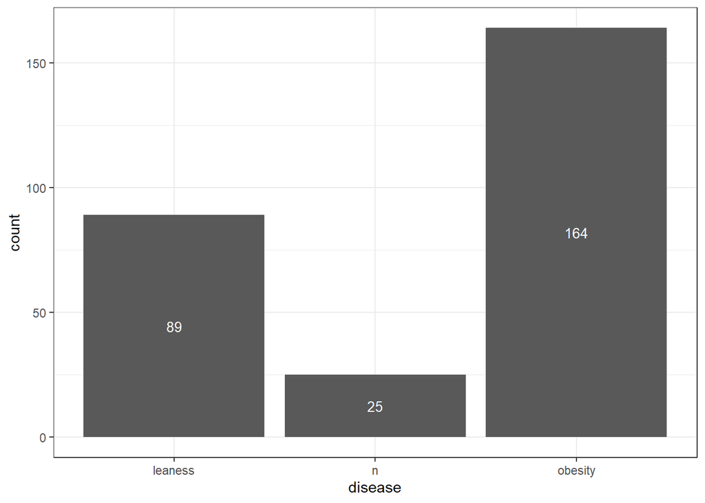

```r
## plot
ggplot(microbiome, aes(x=disease)) +
  geom_bar() +
  theme_bw() +
stat_count(geom = "text",
           colour = "white", size = 3.5,
           aes(label = ..count..),
           position=position_stack(vjust=0.5)
           )
```

3. In column `disease` change the `n` to `NA` to identify the uknown.

```r
microbiome[disease == "n", disease := NA]
```

4. Do the `uknown` have similar BMI as the obese ones? Investigate this using both visualization and statistical testing.

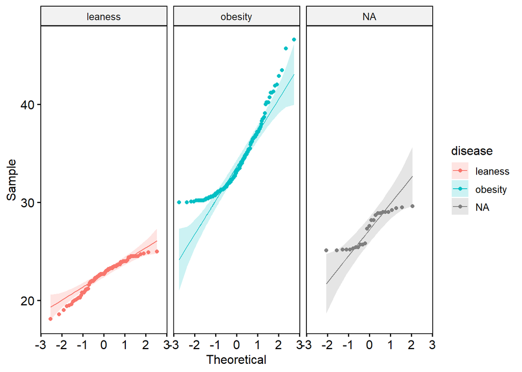

```r
#
ggqqplot(microbiome, x = "bmi",
         color = "disease",
         facet.by = "disease") +
  theme(legend.position = "right")
```

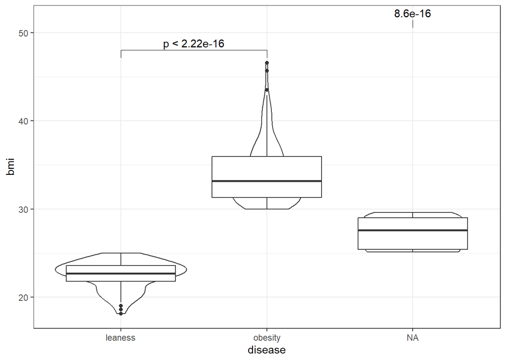

```r
###

ggplot(microbiome, aes(x=disease, y=bmi)) +
  geom_violin() +
  geom_boxplot() +
  theme_bw() +
  ggpubr::stat_compare_means(
    comparison = list(c("leaness", "obesity"),
                      c(NA, "obesity") )
    )
```

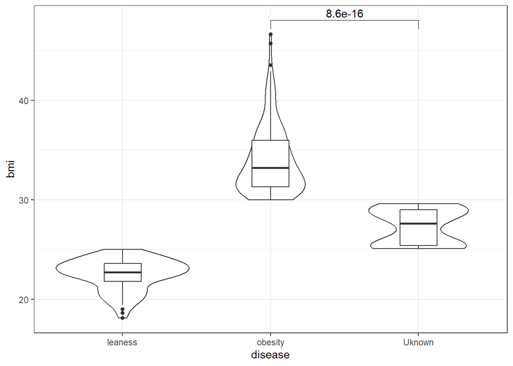

```r
##
microbiome[is.na(disease), disease := "Uknown"]
ggplot(microbiome, aes(x=disease, y=bmi)) +
  geom_violin() +
  geom_boxplot(width= 0.25) +
  theme_bw() +
  ggpubr::stat_compare_means(
    comparisons = list(
                      c("Uknown", "obesity")
                      )
  )
```

```r
# Ukoliko koristimo test
wilcox.test(bmi ~ disease, data= microbiome[disease != "leaness"])
```

```
    Wilcoxon rank sum test with continuity correction

data:  bmi by disease
W = 4100, p-value = 8.633e-16
alternative hypothesis: true location shift is not equal to 0
```

5. Visualize the distribution of `s__Barnesiella_intestinihominis` per `disease`. Perform the appropriate test to determine if there is a significant difference.

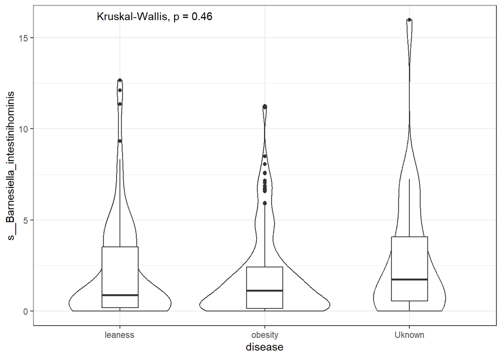

```r
ggplot(microbiome, aes(x=disease, y=s__Barnesiella_intestinihominis)) +
  geom_violin() +
  geom_boxplot(width= 0.25) +
  theme_bw() +
  ggpubr::stat_compare_means()
```

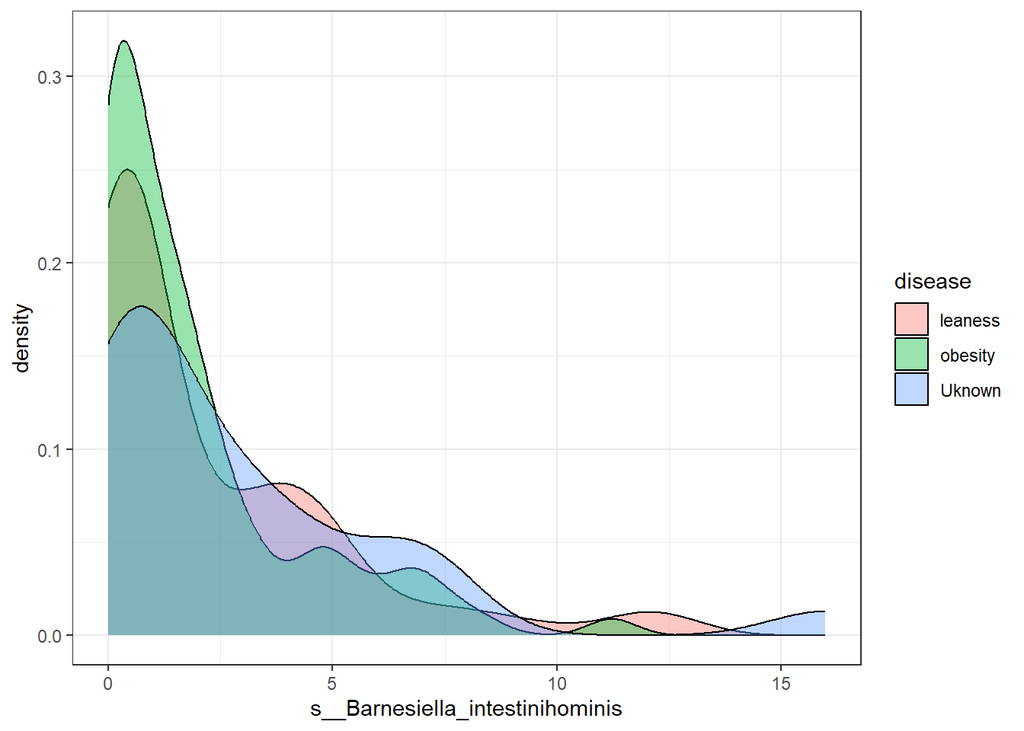

```r
ggplot(microbiome, aes(x=s__Barnesiella_intestinihominis, fill=disease)) +
  geom_density(alpha=0.4) +
  theme_bw()
```

```r
###
kruskal.test(s__Barnesiella_intestinihominis ~ disease,
             data = microbiome)
```

```
    Kruskal-Wallis rank sum test

data:  s__Barnesiella_intestinihominis by disease
Kruskal-Wallis chi-squared = 1.5579, df = 2, p-value = 0.4589
```

6. Which bacteria is most correlated with BMI?

```r
cor_data <- microbiome[, .SD,.SDcols=is.numeric]
cor_matrix <- cor(cor_data)

###
png("Corr_plot.png", width = 800, height = 800)
corrplot(cor_matrix, method = 'square', type = 'upper', diag = FALSE, tl.col = "black")
dev.off()
```

## Prediction of *`obesity`* status based on the abundance of bacterial species

### Feature selection

1. Set the seed to **18**. Are there any columns that should be excluded from the dataset before modeling? Remove those columns and rows. Hint: You only want to keep those samples who have confirmed **obesity** or **leaness** in column `disease`.

```r
microbiome_clean <- microbiome[!is.na(disease),-c("dataset_name", "bodysite", "sampleID", "bmi")]

microbiome_clean[, disease := factor(disease)]
```

2. Split your data into training and test sets. Consider whether there is anything important to keep in mind when splitting the data - for example, potential data leakage or class imbalance.

```r
# Splitting data into training and testing sets
trainIndex <- createDataPartition(microbiome_clean$disease,
                                  p = 0.7,
                                  list = FALSE,
                                  times = 1)
trainData <- microbiome_clean[trainIndex, ]
testData <- microbiome_clean[-trainIndex, ]

# Print the number of rows in training and testing sets
print(nrow(trainData))
```

```
[1] 196
```

```r
full_model <- glm(disease ~ .,
                  data = trainData,
                  family = binomial)
summary(full_model)
```

```
Call:
glm(formula = disease ~ ., family = binomial, data = trainData)

Coefficients: (9 not defined because of singularities)
                                                                                 Estimate
(Intercept)                                                                    -3.990e-01
s__Bacteroides_dorei                                                            2.431e-02
`s__Bacteroides_dorei|t__Bacteroides_dorei_unclassified`                               NA
s__Bacteroides_uniformis                                                       -1.404e-01
`s__Bacteroides_uniformis|t__Bacteroides_uniformis_unclassified`                2.043e-01
s__Bacteroides_vulgatus                                                         5.278e-02
`s__Bacteroides_vulgatus|t__Bacteroides_vulgatus_unclassified`                         NA
s__Barnesiella_intestinihominis                                                -6.648e-03
`s__Barnesiella_intestinihominis|t__GCF_000296465`                                     NA
s__Prevotella_copri                                                             3.971e-02
`s__Prevotella_copri|t__GCF_000157935`                                                 NA
s__Alistipes_putredinis                                                         4.257e-02
`s__Alistipes_putredinis|t__GCF_000154465`                                             NA
s__Eubacterium_rectale                                                         -3.783e+00
`s__Eubacterium_rectale|t__Eubacterium_rectale_unclassified`                    3.830e+00
s__Eubacterium_siraeum                                                          1.242e-01
`s__Eubacterium_siraeum|t__Eubacterium_siraeum_unclassified`                   -1.594e-01
s__Butyrivibrio_crossotus                                                      -1.299e-02
`s__Butyrivibrio_crossotus|t__GCF_000156015`                                           NA
s__Coprococcus_sp_ART55_1                                                      -8.215e-04
`s__Coprococcus_sp_ART55_1|t__GCF_000210595`                                           NA
s__Faecalibacterium_prausnitzii                                                 1.455e-01
`s__Faecalibacterium_prausnitzii|t__Faecalibacterium_prausnitzii_unclassified` -2.239e-01
s__Ruminococcus_bromii                                                          1.154e-01
`s__Ruminococcus_bromii|t__GCF_000209875`                                              NA
s__Subdoligranulum_unclassified                                                 7.447e-03
s__Dialister_invisus                                                            1.260e-03
`s__Dialister_invisus|t__GCF_000160055`                                                NA
                                                                               Std. Error
(Intercept)                                                                     8.726e-01
s__Bacteroides_dorei                                                            5.684e-02
`s__Bacteroides_dorei|t__Bacteroides_dorei_unclassified`                               NA
s__Bacteroides_uniformis                                                        1.542e-01
`s__Bacteroides_uniformis|t__Bacteroides_uniformis_unclassified`                1.524e-01
s__Bacteroides_vulgatus                                                         6.178e-02
```

[output cut: 104 more lines]

```
s__Ruminococcus_bromii
`s__Ruminococcus_bromii|t__GCF_000209875`
s__Subdoligranulum_unclassified
s__Dialister_invisus
`s__Dialister_invisus|t__GCF_000160055`
---
Signif. codes:  0 '***' 0.001 '**' 0.01 '*' 0.05 '.' 0.1 ' ' 1

(Dispersion parameter for binomial family taken to be 1)

    Null deviance: 246.15  on 195  degrees of freedom
Residual deviance: 216.18  on 177  degrees of freedom
AIC: 254.18

Number of Fisher Scoring iterations: 13
```

```r
# Perform forward selection & select variables
step_model_for <- stepAIC(full_model,
                          direction = "forward",
                          trace = FALSE)
selected_vars_for <- names(coef(step_model_for))[-1]
selected_vars_for
```

```
 [1] "s__Bacteroides_dorei"
 [2] "`s__Bacteroides_dorei|t__Bacteroides_dorei_unclassified`"
 [3] "s__Bacteroides_uniformis"
 [4] "`s__Bacteroides_uniformis|t__Bacteroides_uniformis_unclassified`"
 [5] "s__Bacteroides_vulgatus"
 [6] "`s__Bacteroides_vulgatus|t__Bacteroides_vulgatus_unclassified`"
 [7] "s__Barnesiella_intestinihominis"
 [8] "`s__Barnesiella_intestinihominis|t__GCF_000296465`"
 [9] "s__Prevotella_copri"
[10] "`s__Prevotella_copri|t__GCF_000157935`"
[11] "s__Alistipes_putredinis"
[12] "`s__Alistipes_putredinis|t__GCF_000154465`"
[13] "s__Eubacterium_rectale"
[14] "`s__Eubacterium_rectale|t__Eubacterium_rectale_unclassified`"
[15] "s__Eubacterium_siraeum"
[16] "`s__Eubacterium_siraeum|t__Eubacterium_siraeum_unclassified`"
[17] "s__Butyrivibrio_crossotus"
[18] "`s__Butyrivibrio_crossotus|t__GCF_000156015`"
[19] "s__Coprococcus_sp_ART55_1"
[20] "`s__Coprococcus_sp_ART55_1|t__GCF_000210595`"
[21] "s__Faecalibacterium_prausnitzii"
[22] "`s__Faecalibacterium_prausnitzii|t__Faecalibacterium_prausnitzii_unclassified`"
[23] "s__Ruminococcus_bromii"
[24] "`s__Ruminococcus_bromii|t__GCF_000209875`"
[25] "s__Subdoligranulum_unclassified"
[26] "s__Dialister_invisus"
[27] "`s__Dialister_invisus|t__GCF_000160055`"
```

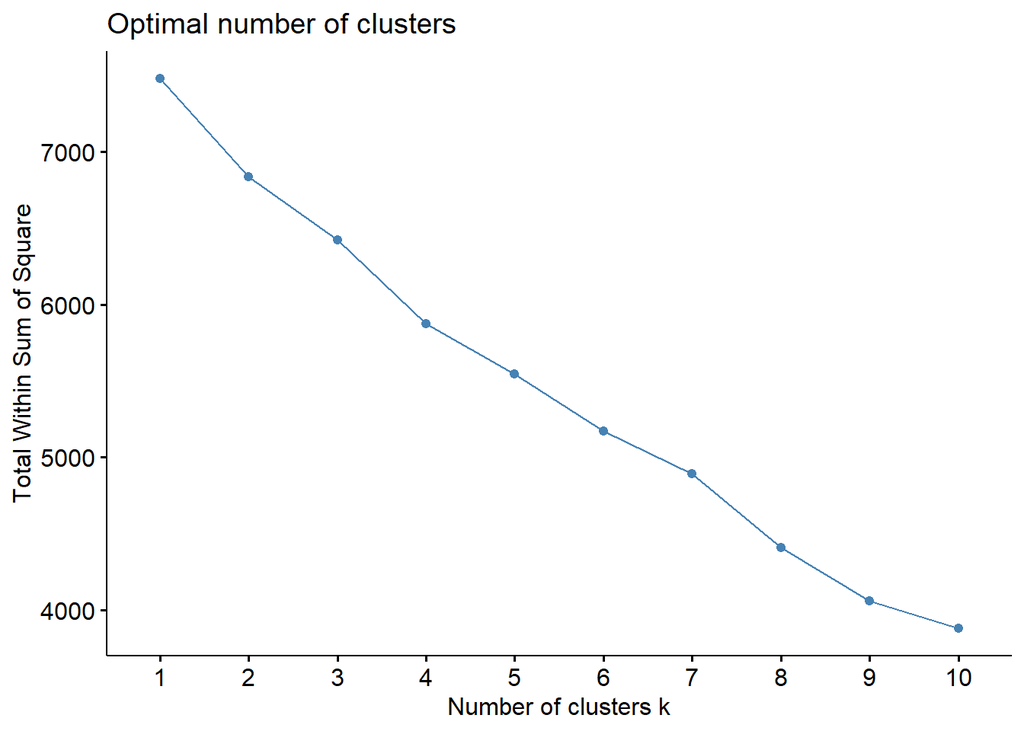

```r
# Remove non-numeric columns (e.g., outcome variable)
numeric_data <- microbiome_clean[, .SD, .SDcols = is.numeric]

# Standardize
scaled_all <- scale(numeric_data)

# Perform k-means on all features
set.seed(123)

# Elbow method
fviz_nbclust(scaled_all,
             kmeans,
             method = "wss")
```

```r
km_all <- kmeans(scaled_all, centers = 2)

# Combine K-means and original label
kmeans_df <- cbind(microbiome_clean,
                   cluster = as.factor(km_all$cluster)
                   )

# How well did k-means clustering do in comparison with known groups?
table(kmeans_df$cluster, kmeans_df$disease)
```

```
    leaness obesity Uknown
  1      19      57      9
  2      70     107     16
```

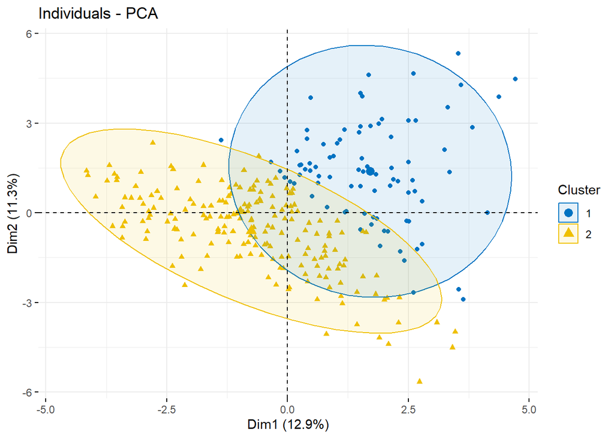

```r
# Visualize PCA with cluster assignment
# Perform PCA on the scaled matrix
pca_all <- prcomp(scaled_all)


# Visualize individuals, colored by cluster
fviz_pca_ind(pca_all,
             geom.ind = "point",
             col.ind = as.factor(km_all$cluster),  # km_all is from kmeans()
             palette = "jco",
             addEllipses = TRUE,
             legend.title = "Cluster")
```

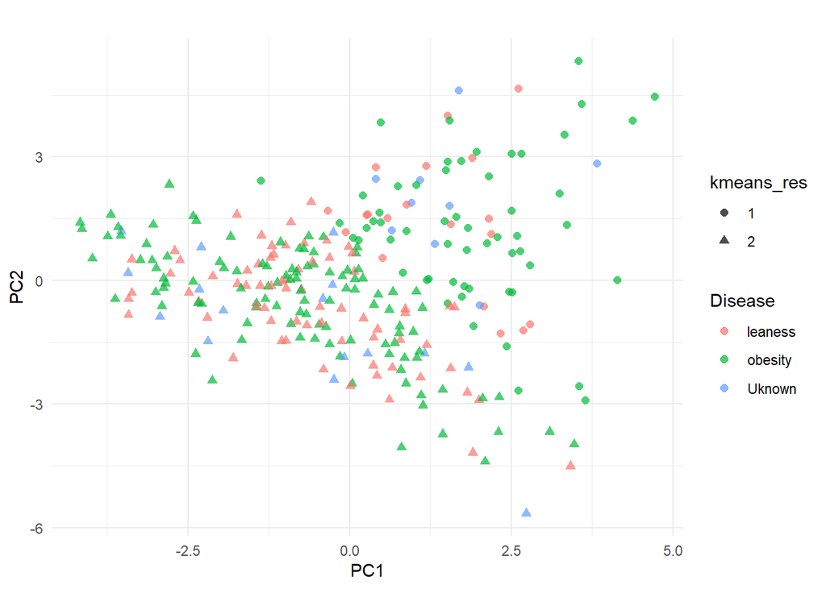

```r
# Combine PCA and original label
pca_df <- data.frame(pca_all$x,
                     disease = microbiome_clean$disease,
                     kmeans_res = as.factor(km_all$cluster))

# Plot PC1 vs PC2 and color by diagnosis
ggplot(pca_df, aes(PC1, PC2, col = disease, shape=kmeans_res)) +
  geom_point(size = 2, alpha = 0.7) +
  theme_minimal() +
  labs(title = "", color = "Disease")
```

1. **Random forest**
2. **Logistic regression**
3. **Bagging**

```r
# seting cross-valudation
ctrl <- trainControl(method = "cv",
                     number = 10)
```

Each group member may select a different model, or you can all use the same one.

- Train the chosen model on the **training dataset**.

```r
model <- train(disease ~ .,
               data = trainData,
               method = "rf",       # or "rf", or "treebag"
               trControl = ctrl,
               family = binomial)

model
```

```
Random Forest

196 samples
 27 predictor
  3 classes: 'leaness', 'obesity', 'Uknown'

No pre-processing
Resampling: Cross-Validated (10 fold)
Summary of sample sizes: 176, 176, 177, 176, 176, 178, ...
Resampling results across tuning parameters:

  mtry  Accuracy   Kappa
   2    0.5813743  0.06082931
  14    0.5913450  0.13213861
  27    0.5805263  0.12818304

Accuracy was used to select the optimal model using the largest value.
The final value used for the model was mtry = 14.
```

- What is the model’s accuracy on the training data?

```r
### confusion matrix and error
table(predict(model, trainData), trainData$disease) %>%
  confusionMatrix()
```

```
Confusion Matrix and Statistics


          leaness obesity Uknown
  leaness      63       0      0
  obesity       0     115      0
  Uknown        0       0     18

Overall Statistics

               Accuracy : 1
                 95% CI : (0.9814, 1)
    No Information Rate : 0.5867
    P-Value [Acc > NIR] : < 2.2e-16

                  Kappa : 1

 Mcnemar's Test P-Value : NA

Statistics by Class:

                     Class: leaness Class: obesity Class: Uknown
Sensitivity                  1.0000         1.0000       1.00000
Specificity                  1.0000         1.0000       1.00000
Pos Pred Value               1.0000         1.0000       1.00000
Neg Pred Value               1.0000         1.0000       1.00000
Prevalence                   0.3214         0.5867       0.09184
Detection Rate               0.3214         0.5867       0.09184
Detection Prevalence         0.3214         0.5867       0.09184
Balanced Accuracy            1.0000         1.0000       1.00000
```

- Plot the ROC curve and report the AUC for the training set.

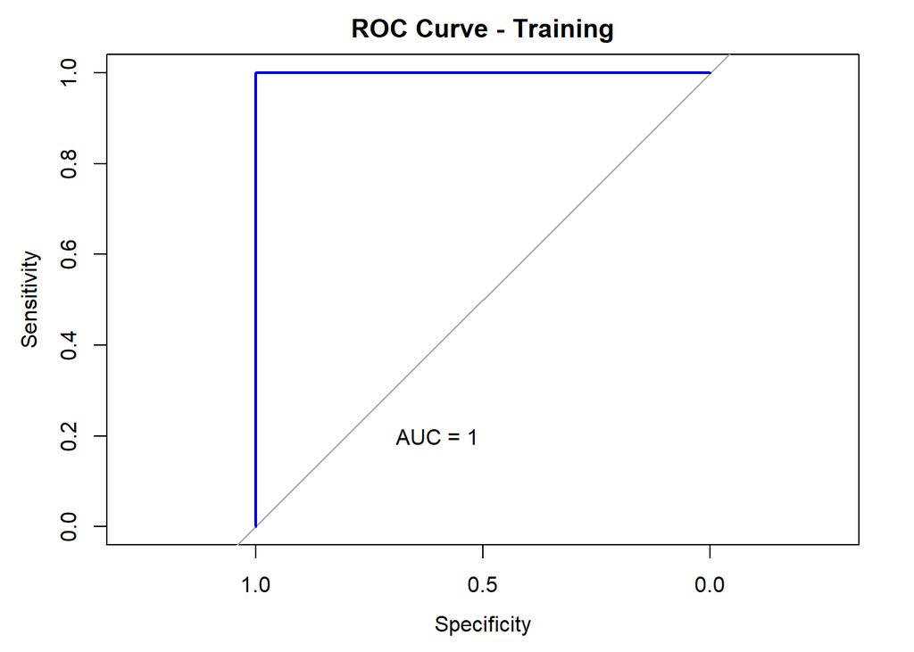

```r
library(pROC)
# Get predicted probabilities for the positive class (e.g. "Yes")
train_probs <- predict(model, newdata = trainData, type = "prob")[, "obesity"]
train_labels <- trainData$disease

# Compute ROC
roc_train <- roc(train_labels, train_probs)

# Plot ROC
plot(roc_train, col = "blue", lwd = 2, main = "ROC Curve - Training")
text(0.6, 0.2, paste("AUC =", round(auc(roc_train), 3)), col = "black")
```

Now evaluate the model on the **test dataset**.

- What is the accuracy on the test set?

```r
# Predicted probabilities and classes
table(predict(model, testData), testData$disease) %>% confusionMatrix()
```

```
Confusion Matrix and Statistics


          leaness obesity Uknown
  leaness       5       8      2
  obesity      20      41      5
  Uknown        1       0      0

Overall Statistics

               Accuracy : 0.561
                 95% CI : (0.447, 0.6704)
    No Information Rate : 0.5976
    P-Value [Acc > NIR] : 0.78544

                  Kappa : 0.0456

 Mcnemar's Test P-Value : 0.01492

Statistics by Class:

                     Class: leaness Class: obesity Class: Uknown
Sensitivity                 0.19231         0.8367       0.00000
Specificity                 0.82143         0.2424       0.98667
Pos Pred Value              0.33333         0.6212       0.00000
Neg Pred Value              0.68657         0.5000       0.91358
Prevalence                  0.31707         0.5976       0.08537
Detection Rate              0.06098         0.5000       0.00000
Detection Prevalence        0.18293         0.8049       0.01220
Balanced Accuracy           0.50687         0.5396       0.49333
```

- Plot the ROC curve and report the AUC for the test set.

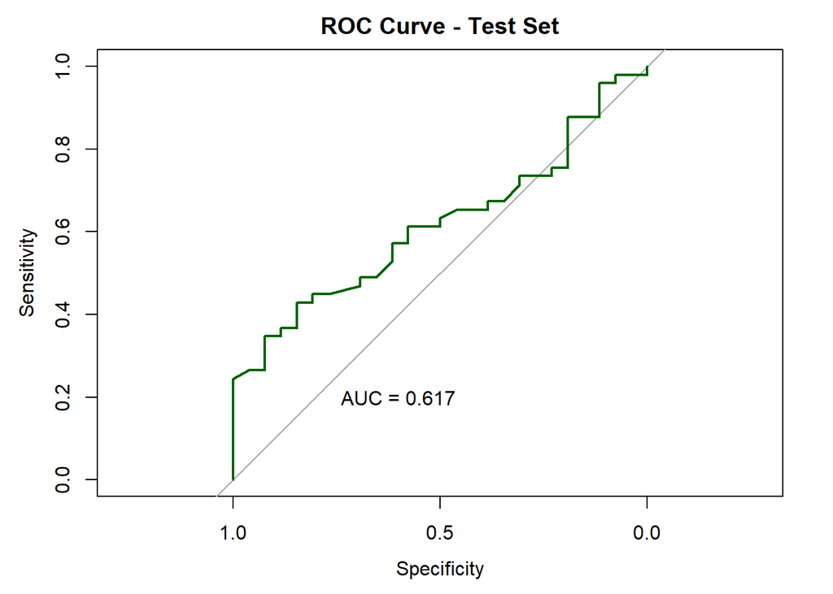

```r
# Predict probabilities for test data
test_probs <- predict(model, newdata = testData, type = "prob")[, "obesity"]
test_labels <- testData$disease

# Compute ROC
roc_test <- roc(test_labels, test_probs)

# Plot ROC
plot(roc_test, col = "darkgreen", lwd = 2, main = "ROC Curve - Test Set")
text(0.6, 0.2, paste("AUC =", round(auc(roc_test), 3)), col = "black")
```

#### What is your overall conclusion?